# Submodels and final models

## 1.3. Pull out the final data again

We will pull out the predictors from the submodels **at the appropriate spatial scales** and merge this into one big dataset for final models. This selects a couple extra columns that we don’t actually want to model but that’s fine, this was efficient. This is the *unscaled* data so that we can run the sampler and apply appropriate constraints before scaling the data again.

```r
data_final <- bind_cols(

  # response variables
  data %>%
    select(1:squirrel) %>%
    distinct(),

  # natural data scaled by natural buffer
  data %>%
    filter(buffer_dist == nat_buffer) %>%
    select(fire_0_15:lc_wetland_treed) %>%
    mutate(natural_buffer = nat_buffer), # won't use this column, just keeping track of the scale somehow

  # composition data scaled by composition buffer
  data %>%
    filter(buffer_dist == comp_buffer) %>%
    select(harvest_0_15:wells_total) %>%
    mutate(comp_buffer = comp_buffer), # won't use this column, just keeping track of the scale somehow

  # configuration data
  data %>%
    filter(buffer_dist == config_buffer) %>%
    select(contains("nonanthro") | contains("landscape") | contains("cfi")) %>%
    mutate(config_buffer = config_buffer) # won't use this column, just keeping track of the scale somehow
  ) %>%

  relocate(contains("buffer"), .after=("squirrel"))

summary(data_final)
```

```
##     array               site               month             year
##  Length:4918        Length:4918        Min.   : 1.000   Min.   :2021
##  Class :character   Class :character   1st Qu.: 4.000   1st Qu.:2022
##  Mode  :character   Mode  :character   Median : 7.000   Median :2023
##                                        Mean   : 6.634   Mean   :2023
##                                        3rd Qu.:10.000   3rd Qu.:2024
##                                        Max.   :12.000   Max.   :2024
##     squirrel       natural_buffer  comp_buffer   config_buffer
##  Min.   : 0.0000   Min.   :100    Min.   :4250   Min.   :2250
##  1st Qu.: 0.0000   1st Qu.:100    1st Qu.:4250   1st Qu.:2250
##  Median : 0.0000   Median :100    Median :4250   Median :2250
##  Mean   : 0.9339   Mean   :100    Mean   :4250   Mean   :2250
##  3rd Qu.: 1.0000   3rd Qu.:100    3rd Qu.:4250   3rd Qu.:2250
##  Max.   :70.0000   Max.   :100    Max.   :4250   Max.   :2250
##    fire_0_15         fire_gt_15     pct_lari_lar       lc_broadleaf
##  Min.   :0.00000   Min.   :0.000   Min.   :0.000000   Min.   :0.000000
##  1st Qu.:0.00000   1st Qu.:0.000   1st Qu.:0.000000   1st Qu.:0.001251
##  Median :0.00000   Median :0.000   Median :0.000000   Median :0.031500
##  Mean   :0.05903   Mean   :0.025   Mean   :0.017705   Mean   :0.165230
##  3rd Qu.:0.00000   3rd Qu.:0.000   3rd Qu.:0.002441   3rd Qu.:0.207147
##  Max.   :0.99998   Max.   :1.000   Max.   :0.410436   Max.   :0.997400
##  lc_coniferous       lc_herbs         lc_mixedwood        lc_shrubs
##  Min.   :0.0000   Min.   :0.000000   Min.   :0.000000   Min.   :0.0000000
##  1st Qu.:0.1166   1st Qu.:0.000000   1st Qu.:0.001708   1st Qu.:0.0000000
##  Median :0.3411   Median :0.004752   Median :0.024024   Median :0.0000000
##  Mean   :0.3693   Mean   :0.030944   Mean   :0.077900   Mean   :0.0254530
##  3rd Qu.:0.5895   3rd Qu.:0.033106   3rd Qu.:0.093809   3rd Qu.:0.0006952
##  Max.   :0.9961   Max.   :0.431069   Max.   :0.710038   Max.   :0.9556450
##     lc_water          lc_wetland       lc_wetland_treed   harvest_0_15
##  Min.   :0.000000   Min.   :0.000000   Min.   :0.00000   Min.   :0.000000
##  1st Qu.:0.000000   1st Qu.:0.001763   1st Qu.:0.04007   1st Qu.:0.000000
##  Median :0.000000   Median :0.013062   Median :0.15314   Median :0.000000
##  Mean   :0.002367   Mean   :0.061577   Mean   :0.23877   Mean   :0.015072
##  3rd Qu.:0.000000   3rd Qu.:0.064013   3rd Qu.:0.38478   3rd Qu.:0.009129
##  Max.   :0.180988   Max.   :0.635488   Max.   :0.95080   Max.   :0.190679
##  harvest_gt_15      harvest_total     osm_industrial       pipe_trans
##  Min.   :0.000000   Min.   :0.00000   Min.   :0.000000   Min.   :0.000000
##  1st Qu.:0.000000   1st Qu.:0.00000   1st Qu.:0.001380   1st Qu.:0.001343
##  Median :0.006122   Median :0.01429   Median :0.004808   Median :0.009432
##  Mean   :0.034421   Mean   :0.04964   Mean   :0.017392   Mean   :0.013699
```

[output cut: 36 more lines]

```
##  Max.   :0     Max.   :99.88      Max.   :90.14    Max.   :1246.62
##   landscape_np  landscape_shei   landscape_siei      cfi_site
##  Min.   :  25   Min.   :0.1603   Min.   :0.1494   Min.   :0.00000
##  1st Qu.: 207   1st Qu.:0.5517   1st Qu.:0.6497   1st Qu.:0.02116
##  Median : 349   Median :0.6453   Median :0.7651   Median :0.04418
##  Mean   : 540   Mean   :0.6334   Mean   :0.7280   Mean   :0.06532
##  3rd Qu.: 580   3rd Qu.:0.7238   3rd Qu.:0.8379   3rd Qu.:0.08529
##  Max.   :4255   Max.   :0.9884   Max.   :0.9898   Max.   :0.47178
##  cfi_site_with_harvest cfi_site_with_vegedges
##  Min.   :0.00000       Min.   :0.00000
##  1st Qu.:0.02849       1st Qu.:0.02669
##  Median :0.05899       Median :0.05142
##  Mean   :0.08354       Mean   :0.07503
##  3rd Qu.:0.11090       3rd Qu.:0.09767
##  Max.   :0.54318       Max.   :0.47364
```

## 1.4. Re-fit the top model:

Have to fit using the scaled data. Hacky way to deal with scaling and code is a bit repetitive but it works.

```r
data_final_scaled <- bind_cols(

  # response variables
  data_scaled %>%
    select(1:squirrel) %>%
    distinct(),

  # natural data scaled by natural buffer
  data_scaled %>%
    filter(buffer_dist == nat_buffer) %>%
    select(fire_0_15:lc_wetland_treed) %>%
    mutate(natural_buffer = nat_buffer), # won't use this column, just keeping track of the scale somehow

  # composition data scaled by composition buffer
  data_scaled %>%
    filter(buffer_dist == comp_buffer) %>%
    select(harvest_0_15:wells_total) %>%
    mutate(comp_buffer = comp_buffer), # won't use this column, just keeping track of the scale somehow

  # configuration data
  data_scaled %>%
    filter(buffer_dist == config_buffer) %>%
    select(contains("nonanthro") | contains("landscape") | contains("cfi")) %>%
    mutate(config_buffer = config_buffer) # won't use this column, just keeping track of the scale somehow
  ) %>%

  relocate(contains("buffer"), .after=("squirrel"))

  m_edgeXcfi <- glmmTMB(squirrel ~

                        # natural covariates
                        fire_0_15 +
                        lc_broadleaf +
                        lc_coniferous +
                        lc_mixedwood +

                        # configuration variables
                        #landscape_shei +
                        nonanthro_ed +
                        cfi_site +
                        nonanthro_ed*cfi_site +
                        #landscape_mesh +

                        (1|array/site),

                      data = data_final_scaled,
                      family = nbinom2,
                      na.action = na.fail)

summary(m_edgeXcfi)
```

```
##  Family: nbinom2  ( log )
## Formula:
## squirrel ~ fire_0_15 + lc_broadleaf + lc_coniferous + lc_mixedwood +
##     nonanthro_ed + cfi_site + nonanthro_ed * cfi_site + (1 |      array/site)
## Data: data_final_scaled
##
##      AIC      BIC   logLik deviance df.resid
##   9394.4   9465.9  -4686.2   9372.4     4907
##
## Random effects:
##
## Conditional model:
##  Groups     Name        Variance Std.Dev.
##  site:array (Intercept) 2.502    1.5816
##  array      (Intercept) 0.410    0.6403
## Number of obs: 4918, groups:  site:array, 430; array, 10
##
## Dispersion parameter for nbinom2 family (): 0.811
##
## Conditional model:
##                       Estimate Std. Error z value Pr(>|z|)
## (Intercept)           -1.42793    0.23031  -6.200 5.65e-10 ***
## fire_0_15              0.15770    0.11215   1.406   0.1597
## lc_broadleaf          -0.51842    0.12835  -4.039 5.36e-05 ***
## lc_coniferous         -0.03228    0.11093  -0.291   0.7710
## lc_mixedwood           0.16358    0.09223   1.774   0.0761 .
## nonanthro_ed          -0.08884    0.16631  -0.534   0.5932
## cfi_site               0.29548    0.12080   2.446   0.0144 *
## nonanthro_ed:cfi_site -0.25618    0.10011  -2.559   0.0105 *
## ---
## Signif. codes:  0 '***' 0.001 '**' 0.01 '*' 0.05 '.' 0.1 ' ' 1
```

# 2. Run the simulations

## 2.1. Simulation function

Manually set parameters for debugging the function (eval false)

```r
model = m_edgeXcfi
original_data = data_final
n_array = 10
n_site_per_array = 43
n_obs_per_site = 10
sampler_type = "normal"
```

```r
simulate_top_model <- function(model, original_data, n_array, n_site_per_array, n_obs_per_site, sampler_type){

  # Fixed effects in order of model appearance
  B0 <- fixef(model)$cond[1]
  B1 <- fixef(model)$cond[2]
  B2 <- fixef(model)$cond[3]
  B3 <- fixef(model)$cond[4]
  B4 <- fixef(model)$cond[5]
  B5 <- fixef(model)$cond[6]
  B6 <- fixef(model)$cond[7]
  B7 <- fixef(model)$cond[8]

  # Random effects
  SD_site <- sqrt(as.numeric(summary(model)$varcor$cond[["site:array"]]))
  SD_array <- sqrt(as.numeric(summary(model)$varcor$cond[["array"]]))

  if(sampler_type == "normal"){
    # Generate data values based on normal distribution
    fire_0_15 <- rnorm(100000, mean = mean(original_data$fire_0_15), sd = sd(original_data$fire_0_15))
    lc_broadleaf <- rnorm(100000, mean = mean(original_data$lc_broadleaf), sd = sd(original_data$lc_broadleaf))
    lc_coniferous <- rnorm(100000, mean = mean(original_data$lc_coniferous), sd = sd(original_data$lc_coniferous))
    lc_mixedwood <- rnorm(100000, mean = mean(original_data$lc_mixedwood), sd = sd(original_data$lc_mixedwood))
    nonanthro_ed <- rnorm(100000, mean = mean(original_data$nonanthro_ed), sd = sd(original_data$nonanthro_ed))
    cfi_site <- rnorm(100000, mean = mean(original_data$cfi_site), sd = sd(original_data$cfi_site))
  }


  if(sampler_type == "uniform"){
    # Generate data values based on uniform distribution
    fire_0_15 <- runif(100000, min = min(original_data$fire_0_15), max = max(original_data$fire_0_15))
    lc_broadleaf <- runif(100000, min = min(original_data$lc_broadleaf), max = max(original_data$lc_broadleaf))
    lc_coniferous <- runif(100000, min = min(original_data$lc_coniferous), max = max(original_data$lc_coniferous))
    lc_mixedwood <- runif(100000, min = min(original_data$lc_mixedwood), max = max(original_data$lc_mixedwood))
    nonanthro_ed <- runif(100000, min = min(original_data$nonanthro_ed), max = max(original_data$nonanthro_ed))
    cfi_site <- runif(100000, min = min(original_data$cfi_site), max = max(original_data$cfi_site))
  }

  data_sim <- tibble(
                fire_0_15,
                lc_broadleaf,
                lc_coniferous,
                lc_mixedwood,
                nonanthro_ed,
                cfi_site
                ) %>%

    mutate(landcover = lc_broadleaf + lc_coniferous + lc_mixedwood) %>%

    filter(if_all(everything(), ~ . >= 0),
           landcover<1) %>%

    filter(row_number(.) <= n_array * n_site_per_array) %>%

    # Scale the data using the original scaled values
    mutate(
      fire_0_15 = (fire_0_15 - mean(original_data$fire_0_15, na.rm = TRUE)) / sd(original_data$fire_0_15, na.rm = TRUE),
      lc_broadleaf = (lc_broadleaf - mean(original_data$lc_broadleaf, na.rm = TRUE)) / sd(original_data$lc_broadleaf, na.rm = TRUE),
      lc_coniferous = (lc_coniferous - mean(original_data$lc_coniferous, na.rm = TRUE)) / sd(original_data$lc_coniferous, na.rm = TRUE),
      lc_mixedwood = (lc_mixedwood - mean(original_data$lc_mixedwood, na.rm = TRUE)) / sd(original_data$lc_mixedwood, na.rm = TRUE),
      nonanthro_ed = (nonanthro_ed - mean(original_data$nonanthro_ed, na.rm = TRUE)) / sd(original_data$nonanthro_ed, na.rm = TRUE),
      cfi_site = (cfi_site - mean(original_data$cfi_site, na.rm = TRUE)) / sd(original_data$cfi_site, na.rm = TRUE)
    ) %>%

    mutate(array = paste0("Array", rep(1:n_array, each = n_site_per_array)),
           site = paste0(array, "_", 1:n_site_per_array)) %>%

    crossing(obs = 1:n_obs_per_site, .) %>%

    group_by(array) %>%

    mutate(ranef_array = rnorm(n = 1, mean = 0, sd = SD_array)) %>%

    ungroup() %>%

    group_by(array, site) %>%

    mutate(ranef_site = rnorm(n = 1, mean = 0, sd = SD_site)) %>%

    ungroup() %>%

    mutate(eta = B0 +
               B1 * fire_0_15 +
               B2 * lc_broadleaf +
               B3 * lc_coniferous +
               B4 * lc_mixedwood +
               B5 * nonanthro_ed +
               B6 * cfi_site +
               B7 * nonanthro_ed * cfi_site +
               ranef_array +
               ranef_site,

             mu = exp(eta),

             squirrel = rnbinom(n = n(), mu = mu, size = sigma(model)))

  sim_naive_occ <- data_sim %>%
    group_by(site) %>%
    summarize(dets = max(squirrel)) %>%
    mutate(presence = ifelse(dets > 0, 1, 0)) %>%
    summarize(sum(presence)) %>%
    as.numeric()

  sim_indet <- sum(data_sim$squirrel)

  sim <- glmmTMB(squirrel ~

                            # natural covariates
                            fire_0_15 +
                            lc_broadleaf +
                            lc_coniferous +
                            lc_mixedwood +

                            # configuration variables
                            #landscape_shei +
                            nonanthro_ed +
                            cfi_site +
                            nonanthro_ed*cfi_site +
                            #landscape_mesh +

                            (1|array/site),

                          data = data_sim,
                          family = nbinom2,
                          na.action = na.fail)


  sim_summary <- tibble(cov = names(fixef(sim)$cond),
                value = fixef(sim)$cond) %>%

      pivot_wider(names_from = cov) %>%

      mutate(`site:array` = sqrt(as.numeric(VarCorr(sim)$cond[[1]])),
             array = sqrt(as.numeric(VarCorr(sim)$cond[[2]])),
             convergence = sim$fit$convergence,
             n_array = n_array,
             n_site_per_array = n_site_per_array,
             n_obs_per_site = n_obs_per_site,
             sim_indet = sim_indet,
             sim_naive_occ = sim_naive_occ,
             sampler_type = sampler_type,
             sim_date = as.character(Sys.Date()),
             )

  # Only return a model if it converged
  #if(sim$fit$convergence==0){
  #  return(sim_summary)
  #}

}
```

## 2.2. Run simulations

Erase all previous simulations:

```r
sim_master_results <- list()
save(sim_master_results, file = "./data/raw/simulation_checkpoint.RData")
```

Run a fresh set of 1000 simulations (in batches of 10) for each combination of parameters that we want.

```r
# 1000 simulations with normal sampler
for(i in 1:100) {

cat("\r\r Working on `normal` batch", i)

load("./data/raw/simulation_checkpoint.RData")

sim_results <- purrr::map_dfr(1:10, ~
                 simulate_top_model(model = m_edgeXcfi,
                                    original_data = data_final,
                                    n_array = 10,
                                    n_site_per_array = 43,
                                    n_obs_per_site = 10,
                                    sampler_type = "normal"
                                    )
                 )

sim_master_results[[length(sim_master_results)+1]] <- sim_results

save(sim_master_results, file = "./data/raw/simulation_checkpoint.RData")
}

# 1000 simulations with uniform sampler
for(i in 1:100) {

cat("\r\r Working on `uniform` batch", i)

load("./data/raw/simulation_checkpoint.RData")

sim_results <- purrr::map_dfr(1:10, ~
                 simulate_top_model(model = m_edgeXcfi,
                                    original_data = data_final,
                                    n_array = 10,
                                    n_site_per_array = 43,
                                    n_obs_per_site = 10,
                                    sampler_type = "uniform"
                                    )
                 )

sim_master_results[[length(sim_master_results)+1]] <- sim_results

save(sim_master_results, file = "./data/raw/simulation_checkpoint.RData")
}

# 1000 simulations with reduced sites per array
for(i in 1:100) {

cat("\r\r Working on `reduced sites` batch", i)

load("./data/raw/simulation_checkpoint.RData")

sim_results <- purrr::map_dfr(1:10, ~
                 simulate_top_model(model = m_edgeXcfi,
                                    original_data = data_final,
                                    n_array = 10,
                                    n_site_per_array = 22,
                                    n_obs_per_site = 10,
                                    sampler_type = "uniform"
                                    )
                 )

sim_master_results[[length(sim_master_results)+1]] <- sim_results

save(sim_master_results, file = "./data/raw/simulation_checkpoint.RData")
}
```

# 3. Visualize results of the simulations

Let’s take a look at the master results

```r
load("./data/raw/simulation_checkpoint.RData")

# Fetch the simulation results
sim_master_results_df <-  sim_master_results %>%
    bind_rows() %>%
    distinct() # Make sure there are no duplicate simulations.
```

Let’s also import the pretty names

```r
pretty_names <- read_csv("./tables/OSM_all_covariates_formatted_names.csv")
```

Plot using the normal (Gaussian) sampler

```r
true_vals_fixef <- enframe(fixef(m_edgeXcfi)$cond, name = "term", value = "value")

true_vals_ranef <- enframe(VarCorr(m_edgeXcfi)$cond, name = "term", value = "value") %>%
  mutate(value = sqrt(as.numeric(value)))

true_vals <- bind_rows(true_vals_fixef,
                       true_vals_ranef)


# Run simulations
sim_coefficient_plots <- purrr::map(true_vals$term, ~{

  # Pretty label for the plot
  label <- (pretty_names %>% filter(Covariate == .x))$PrettyName

  true_val <- (true_vals %>% filter(term==.x))$value

  # Fetch the simulation results
  sim_master_results_df %>%

    # For a specific subset of simulations
    filter(sampler_type == "normal",
           n_site_per_array == 43,
           convergence == 0) %>%

    # Pivot to long format to make our lives easier in purrr
    pivot_longer(., cols = 1:10) %>%

    # Coefficient values for just the variable we want
    filter(name == .x) %>%

    # Plot it
    ggplot(., aes(x = value)) +

      geom_vline(xintercept = 0, color = "grey70") +  # Dotted vertical line at x = 0

      geom_density(fill = ifelse(str_detect(label, "Random")==TRUE, "darkblue", "darkred"), alpha = 0.3) +

      geom_vline(xintercept = true_val,
                 linetype = "dashed",
                 color = ifelse(str_detect(label, "Random")==TRUE, "darkblue", "darkred"),
                 linewidth=0.8) +  # Dotted vertical line at x = 0

        # Crop the axis since model weights are low
      scale_y_continuous(expand = expansion(mult = c(0, 0.05))) +

      scale_x_continuous(limits = c(true_val-0.75, true_val+0.75), expand = c(0,0)) +

      labs(y = "",
           x = "",
           title = label) +

      theme_bw() +

      theme(panel.grid = element_blank())  # Remove background panel grid
})

ggpubr::ggarrange(plotlist = sim_coefficient_plots, ncol = 3, nrow = 4) +
  bgcolor("white")

ggsave("./figures/top_model_simulations_coefficient_density_gaussian_sampler.png", width =9, height = 8)
```

[output not shown]

Plot using the uniform distribution sampler

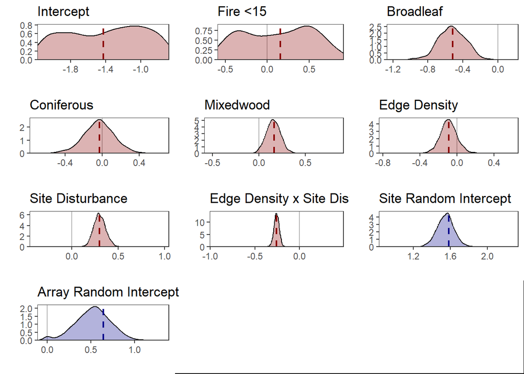

```r
true_vals_fixef <- enframe(fixef(m_edgeXcfi)$cond, name = "term", value = "value")

true_vals_ranef <- enframe(VarCorr(m_edgeXcfi)$cond, name = "term", value = "value") %>%
  mutate(value = sqrt(as.numeric(value)))

true_vals <- bind_rows(true_vals_fixef,
                       true_vals_ranef)


# Run simulations
sim_coefficient_plots <- purrr::map(true_vals$term, ~{

  # Pretty label for the plot
  label <- (pretty_names %>% filter(Covariate == .x))$PrettyName

  true_val <- (true_vals %>% filter(term==.x))$value

  # Fetch the simulation results
  sim_master_results_df %>%

    # For a specific subset of simulations
    filter(sampler_type == "uniform",
           n_site_per_array == 43,
           convergence == 0) %>%

    # Pivot to long format to make our lives easier in purrr
    pivot_longer(., cols = 1:10) %>%

    # Coefficient values for just the variable we want
    filter(name == .x) %>%

    # Plot it
    ggplot(., aes(x = value)) +

      geom_vline(xintercept = 0, color = "grey70") +  # Dotted vertical line at x = 0

      geom_density(fill = ifelse(str_detect(label, "Random")==TRUE, "darkblue", "darkred"), alpha = 0.3) +

      geom_vline(xintercept = true_val,
                 linetype = "dashed",
                 color = ifelse(str_detect(label, "Random")==TRUE, "darkblue", "darkred"),
                 linewidth=0.8) +  # Dotted vertical line at x = 0

        # Crop the axis since model weights are low
      scale_y_continuous(expand = expansion(mult = c(0, 0.05))) +

      scale_x_continuous(limits = c(true_val-0.75, true_val+0.75), expand = c(0,0)) +

      labs(y = "",
           x = "",
           title = label) +

      theme_bw() +

      theme(panel.grid = element_blank())  # Remove background panel grid
})

ggpubr::ggarrange(plotlist = sim_coefficient_plots, ncol = 3, nrow = 4) +
  bgcolor("white")
```

```r
ggsave("./figures/top_model_simulations_coefficient_density_uniform_sampler.png", width = 9, height = 8)
```

Plot using the uniform sampler *and* reduced sample size

```r
true_vals_fixef <- enframe(fixef(m_edgeXcfi)$cond, name = "term", value = "value")

true_vals_ranef <- enframe(VarCorr(m_edgeXcfi)$cond, name = "term", value = "value") %>%
  mutate(value = sqrt(as.numeric(value)))

true_vals <- bind_rows(true_vals_fixef,
                       true_vals_ranef)


# Run simulations
sim_coefficient_plots <- purrr::map(true_vals$term, ~{

  # Pretty label for the plot
  label <- (pretty_names %>% filter(Covariate == .x))$PrettyName

  true_val <- (true_vals %>% filter(term==.x))$value

  # Fetch the simulation results
  sim_master_results_df %>%

    # For a specific subset of simulations
    filter(sampler_type == "uniform",
           n_site_per_array == 22,
           convergence == 0) %>%

    # Pivot to long format to make our lives easier in purrr
    pivot_longer(., cols = 1:10) %>%

    # Coefficient values for just the variable we want
    filter(name == .x) %>%

    # Plot it
    ggplot(., aes(x = value)) +

      geom_vline(xintercept = 0, color = "grey70") +  # Dotted vertical line at x = 0

      geom_density(fill = ifelse(str_detect(label, "Random")==TRUE, "darkblue", "darkred"), alpha = 0.3) +

      geom_vline(xintercept = true_val,
                 linetype = "dashed",
                 color = ifelse(str_detect(label, "Random")==TRUE, "darkblue", "darkred"),
                 linewidth=0.8) +  # Dotted vertical line at x = 0

        # Crop the axis since model weights are low
      scale_y_continuous(expand = expansion(mult = c(0, 0.05))) +

      scale_x_continuous(limits = c(true_val-0.75, true_val+0.75), expand = c(0,0)) +

      labs(y = "",
           x = "",
           title = label) +

      theme_bw() +

      theme(panel.grid = element_blank())  # Remove background panel grid
})

ggpubr::ggarrange(plotlist = sim_coefficient_plots, ncol = 3, nrow = 4) +
  bgcolor("white")

ggsave("./figures/top_model_simulations_coefficient_density_reduced_sample_size.png", width = 9, height = 8)
```

[output not shown]

Let’s look at some summary statistics for our empirical samples. Do they match the simulations?

```r
true_vals <- enframe(fixef(m_edgeXcfi)$cond, name = "term", value = "mean_model")
true_se <- enframe(summary(m_edgeXcfi)$coefficients$cond[, "Std. Error"], name = "term", value = "se_model")

  # Fetch the simulation results
sim_uniform_results <- sim_master_results_df %>%

    # For a specific subset of simulations
    filter(sampler_type == "uniform",
           n_site_per_array == 43,
           convergence == 0) %>%

  select(1:8) %>%

  mutate(sim_id = row_number()) %>%

  pivot_longer(., cols = 1:8, names_to = "term") %>%

  group_by(term) %>%

  summarize(
    mean_estimate = mean(value),
    se_estimate = sd(value)
  ) %>%

  left_join(true_vals, by = "term") %>%

  left_join(true_se, by = "term") %>%

  mutate(mean_bias = mean_estimate - mean_model,
         se_ratio = se_estimate / se_model)%>%

  select(term, contains("mean"), contains("se")) %>%

  arrange(mean_bias)

sim_uniform_results
```

```
## # A tibble: 8 × 7
##   term          mean_estimate mean_model mean_bias se_estimate se_model se_ratio
##   <chr>                 <dbl>      <dbl>     <dbl>       <dbl>    <dbl>    <dbl>
## 1 lc_mixedwood         0.157      0.164  -0.00647       0.0760   0.0922    0.824
## 2 lc_coniferous       -0.0384    -0.0323 -0.00608       0.164    0.111     1.48
## 3 lc_broadleaf        -0.524     -0.518  -0.00548       0.155    0.128     1.21
## 4 nonanthro_ed…       -0.257     -0.256  -0.000673      0.0293   0.100     0.293
## 5 nonanthro_ed        -0.0890    -0.0888 -0.000197      0.0889   0.166     0.535
## 6 cfi_site             0.299      0.295   0.00344       0.0641   0.121     0.530
## 7 (Intercept)         -1.40      -1.43    0.0310        0.949    0.230     4.12
## 8 fire_0_15            0.289      0.158   0.131         3.72     0.112    33.1
```

```r
summary(m_edgeXcfi)
```

```
##  Family: nbinom2  ( log )
## Formula:
## squirrel ~ fire_0_15 + lc_broadleaf + lc_coniferous + lc_mixedwood +
##     nonanthro_ed + cfi_site + nonanthro_ed * cfi_site + (1 |      array/site)
## Data: data_final_scaled
##
##      AIC      BIC   logLik deviance df.resid
##   9394.4   9465.9  -4686.2   9372.4     4907
##
## Random effects:
##
## Conditional model:
##  Groups     Name        Variance Std.Dev.
##  site:array (Intercept) 2.502    1.5816
##  array      (Intercept) 0.410    0.6403
## Number of obs: 4918, groups:  site:array, 430; array, 10
##
## Dispersion parameter for nbinom2 family (): 0.811
##
## Conditional model:
##                       Estimate Std. Error z value Pr(>|z|)
## (Intercept)           -1.42793    0.23031  -6.200 5.65e-10 ***
## fire_0_15              0.15770    0.11215   1.406   0.1597
## lc_broadleaf          -0.51842    0.12835  -4.039 5.36e-05 ***
## lc_coniferous         -0.03228    0.11093  -0.291   0.7710
## lc_mixedwood           0.16358    0.09223   1.774   0.0761 .
## nonanthro_ed          -0.08884    0.16631  -0.534   0.5932
## cfi_site               0.29548    0.12080   2.446   0.0144 *
## nonanthro_ed:cfi_site -0.25618    0.10011  -2.559   0.0105 *
## ---
## Signif. codes:  0 '***' 0.001 '**' 0.01 '*' 0.05 '.' 0.1 ' ' 1
```

End script